# Optimization and Population Modeling

Anurag Amin[^1]

08 February 2018

# 1 Introduction

In this homework we will complete three problems, first deriving foundational results concerning maximum likelihood estimators and resultant expectancy, and then analyzing a population model generated by a differential equation. After the completing these derivations, we will test the accuracy of these estimates using an artificially provided sample. Graphs will be implemented periodically to aid in our analysis.

# 2 Problem 1

$$\begin{equation}
\begin{split}
\\
\ell(\theta) &= ln(L(\theta))\\
&= ln\prod\limits_{i=1}^n f(x_{i}|\theta)\\
&= \sum\limits_{i=1}^n ln(f(x_{i}|\theta))\\
&= \sum\limits_{i=1}^n ln\frac{1}{\pi[1 +(x_{i} - \theta)^2]}\\
&= \sum\limits_{i=1}^n -ln[1 + (\theta - x_{i})^2] - ln(\pi)\\
\ell(\theta) &= -ln(\pi)n - \sum\limits_{i=1}^n ln[1 + (\theta - x_{i})^2]\\
\\
\ell'(\theta) &= \sum\limits_{i=1}^n [ln(1 + (\theta - x_{i})^2)]'\\
&= -\sum\limits_{i=1}^n \frac{2(\theta - x_{i})}{1 + (\theta - x_{i})^2}\\
\ell'(\theta) &= -2\sum\limits_{i=1}^n \frac{(\theta - x_{i})}{1 + (\theta - x_{i})^2}\\
\\
\ell''(\theta) &= -2\sum\limits_{i=1}^n \frac{(1)(1 + (\theta - x_{i})^2)) - 2(\theta - x_{i})^2)}{[1 + (\theta - x_{i})^2]^2}\\
&= -2\sum\limits_{i=1}^n \frac{1 - (\theta - x_{i})^2}{[1 + (\theta - x_{i})^2)]^2}\\
\\
I(\theta) &= n\int \cfrac{[p'(x)]^2}{p(x)}\\
&= \cfrac{4n}{\pi} \int_{-\infty}^{\infty} \cfrac{x^2dx}{(1+x^2)^3}\\
\\
\end{split}
\end{equation}$$
$$\begin{align}
Let\hspace{1mm}us\hspace{1mm} substitute\hspace{2mm} x = \tan(t)\hspace{2mm} where\hspace{2mm} t\in (-\cfrac{\pi}{2},\cfrac{\pi}{2}), \hspace{1mm}we\hspace{1mm} get:\\
\end{align}$$
$$\begin{equation}
\begin{split}
I(\theta) &= \cfrac{4n}{\pi} \int_{-\cfrac{\pi}{2}}^{\cfrac{\pi}{2}} \cfrac{\tan^2(t)d(\tan(t))}{(1+tan^2(t))^3}\\
&= \cfrac{4n}{\pi} \int_{-\cfrac{\pi}{2}}^{\cfrac{\pi}{2}} \cfrac{\tan^2(t)}{(\cfrac{1}{\sec^2(t)})^3}(\cfrac{1}{\sec^2(t)})dt\\
&= \cfrac{4n}{\pi} \int_{-\cfrac{\pi}{2}}^{\cfrac{\pi}{2}} \cfrac{\sin^2(t)}{\cos^2(t)}\cos^4(t)dt\\
&= \cfrac{4n}{\pi} \int_{-\cfrac{\pi}{2}}^{\cfrac{\pi}{2}}\sin^2(t)\cos^2(t)dt\\
&= \cfrac{4n}{\pi}*\cfrac{\pi}{8}=\cfrac{n}{2}\\
\\
\end{split}
\end{equation}$$

Now we will graph the log-likelihood function and find the MLE for $\theta$ using Newton-Raphson method.

We are given this observed sample -

x <- c(1.77, -0.23, 2.76, 3.80, 3.47, 56.75, -1.34, 4.24, -2.44, 3.29, 3.71, -2.40, 4.53, -0.07, -1.05, -13.87, -2.53, -1.75)

Here is the graph of the log-likelihood function -

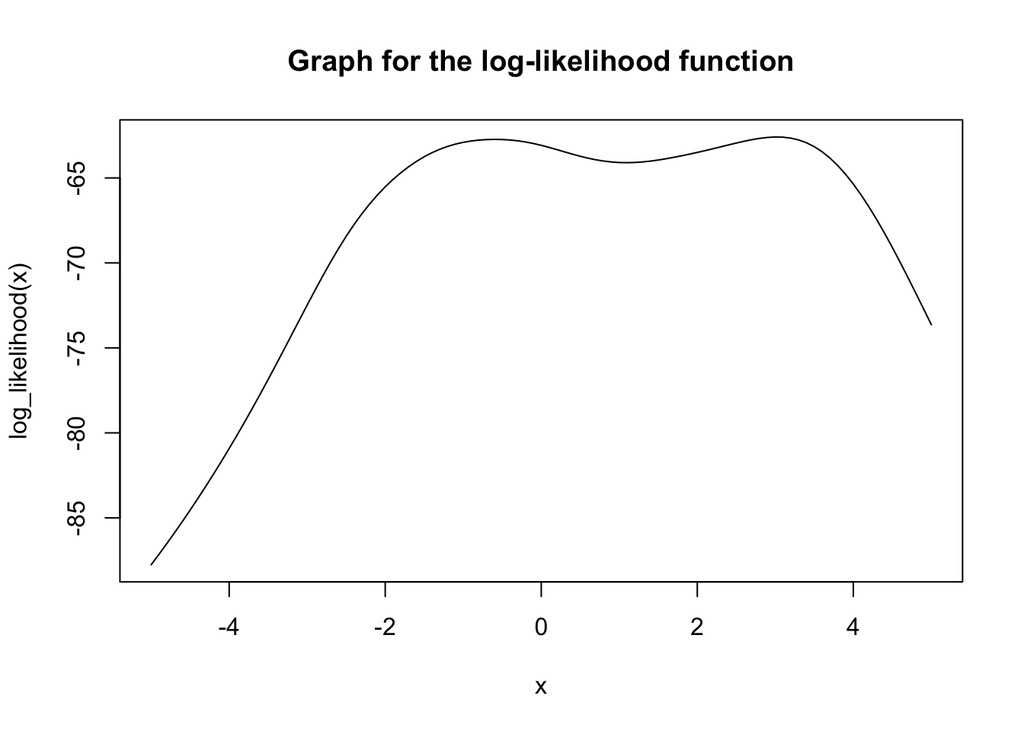

Now, we will repeat the process for various given starting points -

```
## Number of iterations required for convergence with -11 as the starting point:  735
```

```
## Number of iterations required for convergence with -1 as the starting point:  734
```

```
## Number of iterations required for convergence with 0 as the starting point:  4
```

```
## Number of iterations required for convergence with 1.5 as the starting point:  5
```

```
## Number of iterations required for convergence with 4 as the starting point:  736
```

```
## Number of iterations required for convergence with 4.7 as the starting point:  736
```

```
## Number of iterations required for convergence with 7 as the starting point:  736
```

```
## Number of iterations required for convergence with 8 as the starting point:  735
```

```
## Number of iterations required for convergence with 38 as the starting point:  733
```

Let’s see if the mean of the sample space is a good starting point -

```
## Number of iterations required for convergence with the mean of the sample as the starting point:  736
```

As we can see from the results, number of iterations required to achieve convergence for most of the given starting points are very high (in the 700s). Even taking the sample mean as the starting point didn’t help. However, taking 0 as the starting point only required 4 iterations. Hence, we can conclude that 0 is the best starting point for our analysis.

Now, we will try the fixed-point method to carry out our iterations. Here’s the code chunk and solution -

```r
fixedpointiterations <- function(fun, x0, tol=.00000001, niter=500){
  oldxvalue <- x0
  newxvalue <- fun(oldxvalue)
  for(i in 1:niter){
    oldxvalue <- newxvalue
    newxvalue <- fun(oldxvalue)
    if(abs((newxvalue - oldxvalue)) < tol)
      return(newxvalue)
  }
  stop
  return(NULL)
}

dlogp <- function(theta, x) {
  -(2 * (theta-x) / (1+(theta-x)^2))
}

Galpha1 <- function(theta) {
  1 * (dlogp(theta, 1.77) + dlogp(theta, -.23) + dlogp(theta, 2.76) + dlogp(theta, 3.80) + dlogp(theta, 3.47) + dlogp(theta, 56.75) + dlogp(theta, -1.34) + dlogp(theta, 4.24) + dlogp(theta, -2.44) + dlogp(theta, 3.29) + dlogp(theta, 3.71) + dlogp(theta, -2.40) + dlogp(theta, 4.53) + dlogp(theta, -.07) + dlogp(theta, -1.05) + dlogp(theta, -13.87) + dlogp(theta, -2.53) + dlogp(theta, -1.75)) + theta
}

fix1_negative11 <- fixedpointiterations(Galpha1, -11)
fix1_negative11
```

```
## [1] -0.5914735
```

```r
fix1_negative1 <- fixedpointiterations(Galpha1, -1)
fix1_negative1
```

[output not shown]

```r
fix1_0 <- fixedpointiterations(Galpha1, 0)
fix1_0
```

[output not shown]

```r
fix1_1.5 <- fixedpointiterations(Galpha1, 1.5)
fix1_1.5
```

[output not shown]

```r
fix1_4 <- fixedpointiterations(Galpha1, 4)
fix1_4
```

[output not shown]

```r
fix1_4.7 <- fixedpointiterations(Galpha1, 4.7)
fix1_4.7
```

[output not shown]

```r
fix1_7 <- fixedpointiterations(Galpha1, 7)
fix1_7
```

[output not shown]

```r
fix1_8 <- fixedpointiterations(Galpha1, 8)
fix1_8
```

[output not shown]

```r
fix1_38 <- fixedpointiterations(Galpha1, 38)
fix1_38
```

[output not shown]

```r
Galpha0.64 <- function(theta) {
  0.64 * (dlogp(theta, 1.77) + dlogp(theta, -.23) + dlogp(theta, 2.76) + dlogp(theta, 3.80) + dlogp(theta, 3.47) + dlogp(theta, 56.75) + dlogp(theta, -1.34) + dlogp(theta, 4.24) + dlogp(theta, -2.44) + dlogp(theta, 3.29) + dlogp(theta, 3.71) + dlogp(theta, -2.40) + dlogp(theta, 4.53) + dlogp(theta, -.07) + dlogp(theta, -1.05) + dlogp(theta, -13.87) + dlogp(theta, -2.53) + dlogp(theta, -1.75)) + theta
}

fix0.64_negative11 <- fixedpointiterations(Galpha0.64, -11)
fix0.64_negative11
```

```
## [1] -0.5914735
```

```r
fix0.64_negative1 <- fixedpointiterations(Galpha0.64, -1)
fix0.64_negative1
```

```
## [1] -0.5914735
```

```r
fix0.64_0 <- fixedpointiterations(Galpha0.64, 0)
fix0.64_0
```

```
## [1] -0.5914735
```

```r
fix0.64_1.5 <- fixedpointiterations(Galpha0.64, 1.5)
fix0.64_1.5
```

[output not shown]

```r
fix0.64_4 <- fixedpointiterations(Galpha0.64, 4)
fix0.64_4
```

```
## [1] -0.5914735
```

```r
fix0.64_4.7 <- fixedpointiterations(Galpha0.64, 4.7)
fix0.64_4.7
```

```
## [1] -0.5914735
```

```r
fix0.64_7 <- fixedpointiterations(Galpha0.64, 7)
fix0.64_7
```

[output not shown]

```r
fix0.64_8 <- fixedpointiterations(Galpha0.64, 8)
fix0.64_8
```

```
## [1] -0.5914735
```

```r
fix0.64_38 <- fixedpointiterations(Galpha0.64, 38)
fix0.64_38
```

[output not shown]

```r
Galpha0.25 <- function(theta) {
  0.25 * (dlogp(theta, 1.77) + dlogp(theta, -.23) + dlogp(theta, 2.76) + dlogp(theta, 3.80) + dlogp(theta, 3.47) + dlogp(theta, 56.75) + dlogp(theta, -1.34) + dlogp(theta, 4.24) + dlogp(theta, -2.44) + dlogp(theta, 3.29) + dlogp(theta, 3.71) + dlogp(theta, -2.40) + dlogp(theta, 4.53) + dlogp(theta, -.07) + dlogp(theta, -1.05) + dlogp(theta, -13.87) + dlogp(theta, -2.53) + dlogp(theta, -1.75)) + theta
}

fix0.25_negative11 <- fixedpointiterations(Galpha0.25, -11)
fix0.25_negative11
```

```
## [1] -0.5914735
```

```r
fix0.25_negative1 <- fixedpointiterations(Galpha0.25, -1)
fix0.25_negative1
```

```
## [1] -0.5914735
```

```r
fix0.25_0 <- fixedpointiterations(Galpha0.25, 0)
fix0.25_0
```

```
## [1] -0.5914735
```

```r
fix0.25_1.5 <- fixedpointiterations(Galpha0.25, 1.5)
fix0.25_1.5
```

```
## [1] 3.021345
```

```r
fix0.25_4 <- fixedpointiterations(Galpha0.25, 4)
fix0.25_4
```

```
## [1] 3.021345
```

```r
fix0.25_4.7 <- fixedpointiterations(Galpha0.25, 4.7)
fix0.25_4.7
```

```
## [1] 3.021345
```

```r
fix0.25_7 <- fixedpointiterations(Galpha0.25, 7)
fix0.25_7
```

```
## [1] 3.021345
```

```r
fix0.25_8 <- fixedpointiterations(Galpha0.25, 8)
fix0.25_8
```

```
## [1] 3.021345
```

```r
fix0.25_38 <- fixedpointiterations(Galpha0.25, 38)
fix0.25_38
```

```
## [1] 3.021345
```

Soulution and code chunk using Fisher scoring method -

```r
dlogp <- function(theta, x) {
  -( 2 * (theta - x) / (1 + (theta - x)^2))
}

loglikelihood <- function(theta) {
  -(base(theta, 1.77) + base(theta, -.23) + base(theta, 2.76) + base(theta, 3.80) + base(theta, 3.47) + base(theta, 56.75) + base(theta, -1.34) + base(theta, 4.24) + base(theta, -2.44) + base(theta, 3.29) + base(theta, 3.71) + base(theta, -2.40) + base(theta, 4.53) + base(theta, -.07) + base(theta, -1.05) + base(theta, -13.87) + base(theta, -2.53) + base(theta, -1.75))
}

derivativeloglikelihood <- function(theta) {
  (dlogp(theta, 1.77) + dlogp(theta, -0.23) + dlogp(theta, 2.76) +
  dlogp(theta, 3.80) + dlogp(theta, 3.47) + dlogp(theta, 56.75) +
  dlogp(theta, -1.34) + dlogp(theta, 4.24) + dlogp(theta, -2.44) +
  dlogp(theta, 3.29) + dlogp(theta, 3.71) + dlogp(theta, -2.40) +
  dlogp(theta, 4.53) + dlogp(theta, -0.07) + dlogp(theta, -1.05) +
  dlogp(theta, -13.87) + dlogp(theta, -2.53) + dlogp(theta, -1.75))
}

A <- function(x) diag(9, nrow = length(x))

startingpoint_negative11 <- nlminb(-11, loglikelihood, derivativeloglikelihood, A)
startingpoint_negative11
```

```
## $par
## [1] -11
##
## $objective
## [1] 110.0773
##
## $convergence
## [1] 1
##
## $iterations
## [1] 1
##
## $evaluations
## function gradient
##       22        1
##
## $message
## [1] "false convergence (8)"
```

```r
startingpoint_negative1 <- nlminb(-1, loglikelihood, derivativeloglikelihood, A)
startingpoint_negative1
```

```
## $par
## [1] -1
##
## $objective
## [1] 62.90536
##
## $convergence
## [1] 1
##
## $iterations
## [1] 1
##
## $evaluations
## function gradient
##       23        1
##
## $message
## [1] "false convergence (8)"
```

```r
startingpoint_0 <- nlminb(0, loglikelihood, derivativeloglikelihood, A)
startingpoint_0
```

```
## $par
## [1] 0
##
## $objective
## [1] 63.08115
##
## $convergence
## [1] 1
##
## $iterations
## [1] 1
##
## $evaluations
## function gradient
##      200        1
##
## $message
## [1] "function evaluation limit reached without convergence (9)"
```

```r
startingpoint_1.5 <- nlminb(1.5, loglikelihood, derivativeloglikelihood, A)
startingpoint_1.5
```

```
## $par
## [1] 1.5
##
## $objective
## [1] 63.94583
##
## $convergence
## [1] 1
##
## $iterations
## [1] 1
##
## $evaluations
## function gradient
##       23        1
##
## $message
## [1] "false convergence (8)"
```

```r
startingpoint_4 <- nlminb(4, loglikelihood, derivativeloglikelihood, A)
startingpoint_4
```

```
## $par
## [1] 4
##
## $objective
## [1] 65.36038
##
## $convergence
## [1] 1
##
## $iterations
## [1] 1
##
## $evaluations
## function gradient
##       23        1
##
## $message
## [1] "false convergence (8)"
```

```r
startingpoint_4.7 <- nlminb(4.7, loglikelihood, derivativeloglikelihood, A)
startingpoint_4.7
```

```
## $par
## [1] 4.7
##
## $objective
## [1] 70.85886
##
## $convergence
## [1] 1
##
## $iterations
## [1] 1
##
## $evaluations
## function gradient
##       23        1
##
## $message
## [1] "false convergence (8)"
```

```r
startingpoint_7 <- nlminb(7, loglikelihood, derivativeloglikelihood, A)
startingpoint_7
```

```
## $par
## [1] 7
##
## $objective
## [1] 89.29679
##
## $convergence
## [1] 1
##
## $iterations
## [1] 1
##
## $evaluations
## function gradient
##       23        1
##
## $message
## [1] "false convergence (8)"
```

```r
startingpoint_8 <- nlminb(8, loglikelihood, derivativeloglikelihood, A)
startingpoint_8
```

```
## $par
## [1] 8
##
## $objective
## [1] 94.96757
##
## $convergence
## [1] 1
##
## $iterations
## [1] 1
##
## $evaluations
## function gradient
##       23        1
##
## $message
## [1] "false convergence (8)"
```

```r
startingpoint_38 <- nlminb(38, loglikelihood, derivativeloglikelihood, A)
startingpoint_38
```

```
## $par
## [1] 38
##
## $objective
## [1] 149.8628
##
## $convergence
## [1] 1
##
## $iterations
## [1] 1
##
## $evaluations
## function gradient
##       20        1
##
## $message
## [1] "false convergence (8)"
```

# 3 Problem 2

$$p(x;\theta)=\frac{1-\cos(x_i-\theta)}{2\pi}$$
$$l(\theta)=\prod_{i=1}^n \frac{1-\cos(x_i-\theta)}{2\pi}=\sum_{i=1}^n \ln{(1-\cos(x_i-\theta))}-n\ln{2\pi}$$

This is the log-likelihood function of $\theta$ Since the derivative of cos(x) is -sin(x), the derivative of the log-likelihood function will be -

$$l^{'}(\theta)=\sum_{i=1}^n \frac{\sin(\theta-x_i)}{1-\cos(\theta-x_i)}$$

$$l^{''}(\theta)=\sum\limits_{i=1}^n \frac{\cos(\theta-x_i)(1-cos(\theta-x_i))-\sin^2(\theta-x_i)}{(1-\cos(\theta-x_i))^2}=\sum_{i=1}^n \frac{\cos(\theta-x_i)-1}{(1-\cos(\theta-x_i))^2}=\sum_{i=1}^n \frac{1}{\cos(theta-x_i)}$$

The given sample is -

x <- c(3.91, 4.85, 2.28, 4.06, 3.70, 4.04, 5.46, 3.53, 2.28, 1.96, 2.53, 3.88, 2.22, 3.47, 4.82, 2.46, 2.99, 2.54, 0.52)

The mean of the sample is - mean(x) = 3.236842

Now plotting $\ell(\theta)$ -

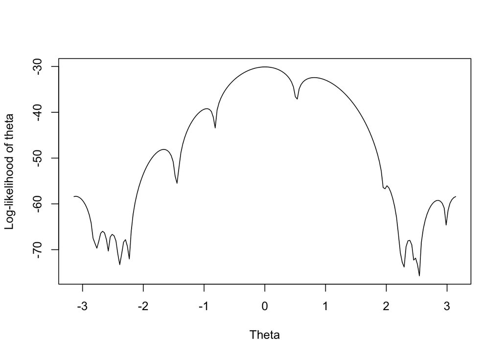

Here, we are asked to find the method-of-moments estimator of $\theta$

$$E[X|\theta]=\frac{1}{2\pi}\int_{0}^{2\pi}x*({1-\cos(x-\theta)})dx=\pi-\frac{1}{2\pi}\int_{0}^{2\pi}x*\cos(x-\theta)dx$$

Integrating by parts yields the following:

$$\int_{0}^{2\pi}x*\cos(x-\theta)dx=x*\sin(x-\theta)|_{0}^{2\pi}-\int_{0}^{2\pi}sin(x-\theta)dx=2\pi\sin(2\pi-\theta)=2\pi\sin(-\theta)=2\pi\sin(\theta)$$

Because $sin(2\pi+x)=sin(x)$ and $\sin(-x)=sin(x)$. We have:

$$E[X|\theta]=\pi-\sin(\theta)$$
Hence, the Method of Moments estimator of $\theta$ is $E[X|\theta]=\overline{X}=\pi-\sin(\theta)\iff\theta_{moment}=\arcsin(\pi-\overline{X})$

```
## [1] -0.09539396
```

Now, we will find the MLE for $\theta$ using the Newton-Raphson method with the method of moments estimator for $\theta$ as the starting point. Here’s the result -

[output not shown]

Starting with $\theta$ values of -2.7 and 2.7 yield the following answers

```
## [1] -2.583716
```

```
## [1] 2.972758
```

respectively.

# 4 Problem 3

Here we fit the population growth model to the beetles data using the Gauss-Newton approach -

```
## 581379.6 :  1030.0    0.2
## 140584 :  947.1168989   0.1418781
## 79987.33 :  1014.9597754    0.1241012
## 73588.69 :  1043.9681300    0.1191291
## 73423.65 :  1048.8120264    0.1184152
## 73419.81 :  1049.3141568    0.1182932
## 73419.7 :  1049.3916987    0.1182726
## 73419.7 :  1049.4046222    0.1182691
## 73419.7 :  1049.4068005    0.1182685
```

```
## Nonlinear regression model
##   model: beetles ~ growthfunc(days, K, r)
##    data: beetles
##         K         r
## 1049.4068    0.1183
##  residual sum-of-squares: 73420
##
## Number of iterations to convergence: 8
## Achieved convergence tolerance: 5.433e-06
```

The contour plot of the sum of squared errors is produced -

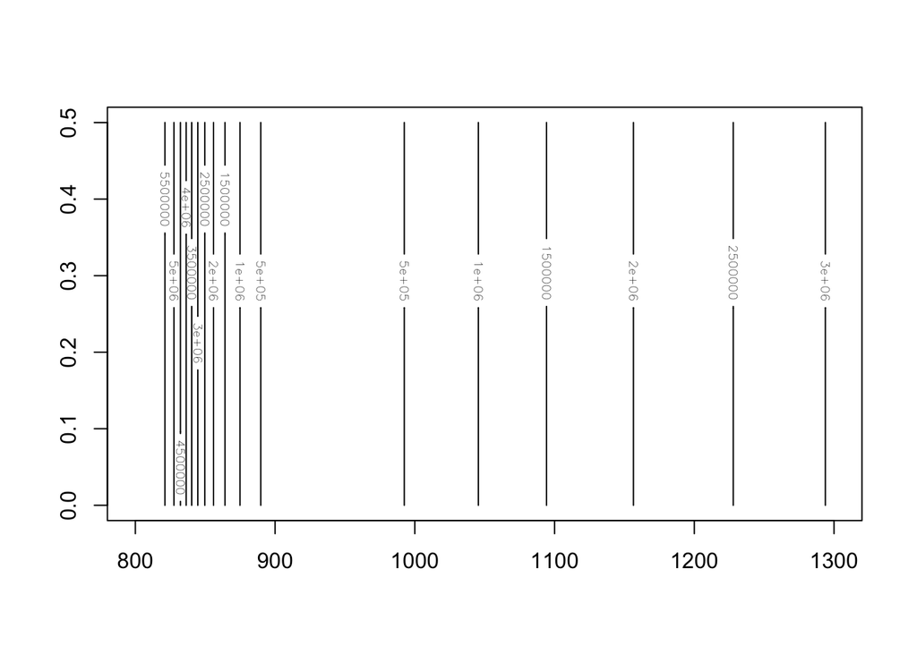

[^1]: anurag.amin@uconn.edu; Master’s student at Department of Mathematics, University of Connecticut.